# Plotting Probability Distributions with ggplot2 and ggfortify

This document explains how to plot probability distributions using `ggplot2` and `ggfortify`.

# Installation

First, install `ggfortify` from [github](https://github.com/sinhrks/ggfortify).

```r
library(devtools)
install_github('sinhrks/ggfortify')
```

# Plotting Probability Distributions

`ggdistribution` is a helper function to plot [Distributions in the stats package](https://stat.ethz.ch/R-manual/R-devel/library/stats/html/Distributions.html) easier using `ggplot2`.

For example, plot standard normal distribution from -3 to +3:

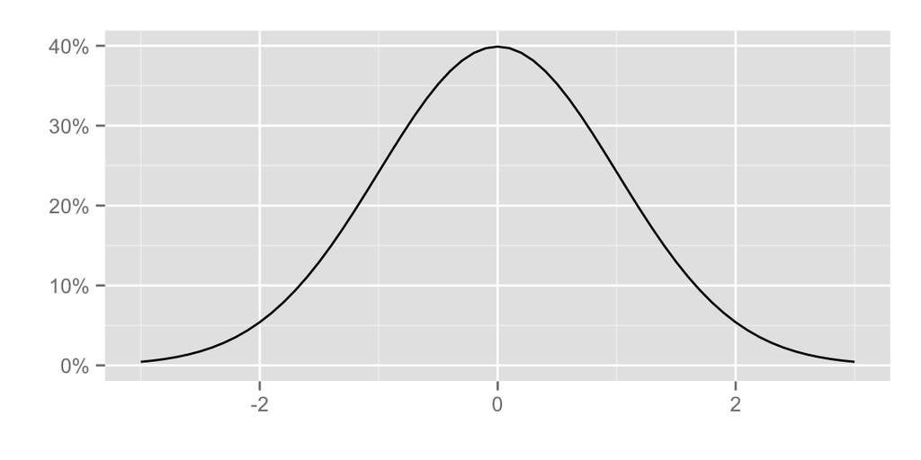

```r
library(ggplot2)
library(ggfortify)
ggdistribution(dnorm, seq(-3, 3, 0.1), mean = 0, sd = 1)
```

`ggdistribution` accepts PDF/CDF function, sequence, and options passed to PDF/CDF function. Also, it has some options to configure how plot looks. Use `help(ggdistribution)` to check available options.

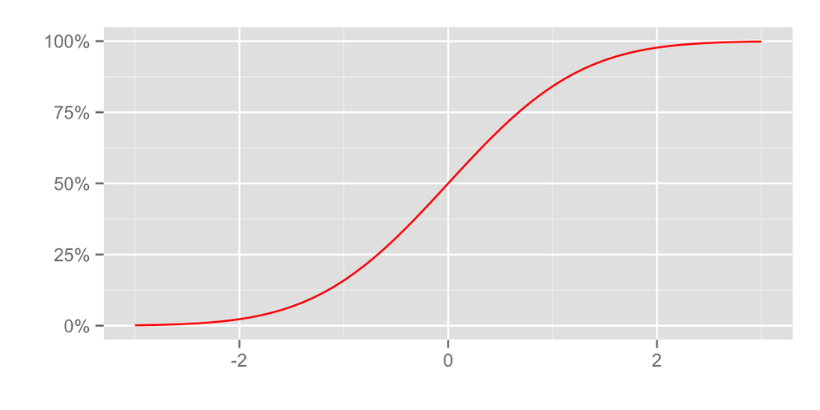

```r
ggdistribution(pnorm, seq(-3, 3, 0.1), mean = 0, sd = 1, colour = 'red')
```

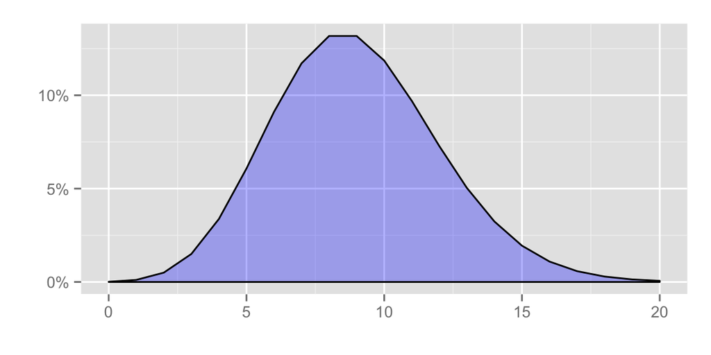

```r
ggdistribution(dpois, seq(0, 20), lambda = 9, fill = 'blue')
```

If you want to plot some distributions overwrapped, use `p` keyword to pass `ggplot` instance.

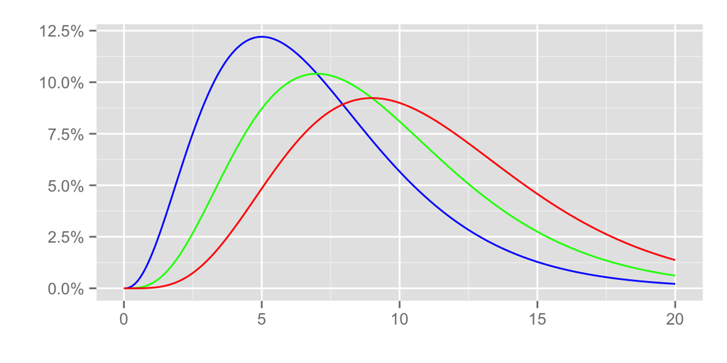

```r
p <- ggdistribution(dchisq, seq(0, 20, 0.1), df = 7, colour = 'blue')
p <- ggdistribution(dchisq, seq(0, 20, 0.1), df = 9, colour = 'green', p = p)
ggdistribution(dchisq, seq(0, 20, 0.1), df = 11, colour = 'red', p = p)
```

# Plotting Density

Also, `autoplot` can accept `stats::density`.

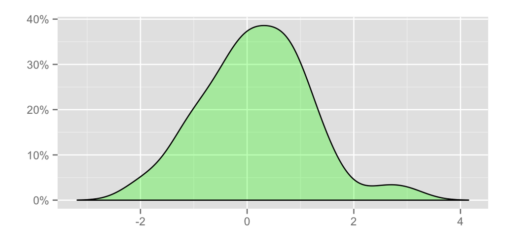

```r
autoplot(density(rnorm(1:50)), fill = 'green')
```

# Resources related to ggfortify

- [Plotting Diagnostics for LM and GLM with ggplot2 and ggfortify](http://rpubs.com/sinhrks/plot_lm)
- [Plotting Time Series with ggplot2 and ggfortify](http://rpubs.com/sinhrks/plot_ts)
- [Plotting Time Series Statistics with ggplot2 and ggfortify](http://rpubs.com/sinhrks/plot_tsstats)
- [Plotting PCA/clustering results using ggplot2 and ggfortify](http://rpubs.com/sinhrks/plot_pca)
- [Plotting Multidimensional Scaling using ggplot2 and ggfortify](http://rpubs.com/sinhrks/plot_mds)
- [Plotting Survival Curves using ggplot2 and ggfortify](http://rpubs.com/sinhrks/plot_surv)
- [Plotting Probability Distributions with ggplot2 and ggfortify](http://rpubs.com/sinhrks/plot_dist)